# Member 4 — Support Vector Machine

STAT5003 Assignment 2: Predicting Match Outcomes in Europe’s Top Five Leagues

Author

Group 2 — Member 4

```r
sp    <- load_split()
train <- sp$train
test  <- sp$test
folds <- readRDS("data/cv_folds.rds")
```

The training set holds 19,985 matches and the Final Test set 5,256. Split, folds and scoring function are Member 5’s shared deliverables — nothing is re-derived here.

# Features and preprocessing

```r
BASE_FEATURES <- c("competition_id", "season_progress")

REFINED_FEATURES <- c("table_pos_diff", "points_per_game_diff", "form_points_diff",
                      "recent_goal_diff", "venue_form_diff", "h2h_diff",
                      "rest_days_diff", "competition_id", "season_progress")
```

SVM needs two preprocessing steps that Random Forest did not.

**Standardisation is mandatory.** The RBF kernel is distance-based, so a variable measured in tens of thousands would dominate one measured in single digits.

**Missing values must be imputed**, since `svm()` cannot accept `NA`. Matchday-1 rows have no prior-match history by construction.

Both are estimated **on the training fold only** and applied unchanged to the validation fold or test set, as required by plan §6.

```r
# Fit centre/scale and medians on the training rows only
fit_prep <- function(d, features) {
  num <- setdiff(features, "competition_id")
  D <- as.data.frame(d)[, num, drop =FALSE]
  list(features = features, num = num,
       med    = vapply(D, median, numeric(1), na.rm = TRUE),
       centre = vapply(D, mean, numeric(1), na.rm = TRUE),
       scale  = vapply(D, function(x) {
                  s <- sd(x, na.rm = TRUE); if (is.na(s) || s == 0) 1 else s }, numeric(1)))
}

# Apply a fitted recipe to any set of rows
apply_prep <- function(prep, d) {
  X <- d[, prep$features, drop = FALSE]
  for (v in prep$num) {
    x <- X[[v]]
    x[is.na(x)] <- prep$med[[v]]                      # impute with training median
    X[[v]] <- (x - prep$centre[[v]]) / prep$scale[[v]] # standardise
  }
  if ("competition_id" %in% prep$features) {
    X$competition_id <- factor(X$competition_id, levels = levels(train$competition_id))
    X <- cbind(X[, prep$num, drop = FALSE],
               model.matrix(~ competition_id - 1, data = X))  # one-hot
  }
  as.matrix(X)
}
```

# Computational cost

Kernel SVM training scales roughly quadratically with sample size. Fold 5 trains on about 18,159 matches, so the grid must be sized against measured runtime rather than guessed.

```r
time_fit <- function(n) {
  idx  <- sample(nrow(train), n)
  prep <- fit_prep(train[idx, ], REFINED_FEATURES)
  X    <- apply_prep(prep, train[idx, ])
  system.time(svm(X, train$result[idx], kernel = "radial",
                  cost = 1, gamma = 1 / ncol(X)))[["elapsed"]]
}

timing <- data.table(n = c(1000, 2000, 4000))
timing[, seconds := vapply(n, time_fit, numeric(1))]
timing[, `scaling vs n=1000` := round(seconds / seconds[1], 1)]
knitr::kable(timing, digits = 2, caption = "Single-fit runtime by training size")
```

Single-fit runtime by training size

| n | seconds | scaling vs n=1000 |
| --- | --- | --- |
| 1000 | 0.05 | 1.0 |
| 2000 | 0.19 | 3.6 |
| 4000 | 0.75 | 14.2 |

```r
# Quadratic extrapolation to the largest fold
largest <- max(sapply(folds, function(f) length(f$train)))
rate    <- timing$seconds[timing$n == 2000] / 2000^2
est_one <- rate * largest^2
cat(sprintf("Estimated single fit on %s rows: %.1f s\n", format(largest, big.mark=","), est_one))
```

```
Estimated single fit on 18,159 rows: 15.7 s
```

```r
cat(sprintf("A 9-point grid across 5 folds would be roughly %.0f min\n",
            9 * 5 * est_one / 60))
```

```
A 9-point grid across 5 folds would be roughly 12 min
```

The measured cost was acceptable, so the full grid was retained. A linear kernel is nonetheless compared below as a kernel-selection check rather than a fallback.

# Hyperparameter tuning

Two parameters are tuned by expanding-window cross-validation, scored on **Macro-F1** using the shared `evaluate_model()`:

- **`cost`** — the penalty for margin violations. Low values give a wider, softer margin and more regularisation; high values fit the training data harder.
- **`gamma`** — the RBF kernel width. Low values make each support vector influence a wide region, giving smoother boundaries.

```r
cv_svm <- function(features, grid, kernel = "radial") {
  rbindlist(lapply(seq_len(nrow(grid)), function(g) {
    f1s <- vapply(folds, function(f) {
      tr <- train[f$train, ]; va <- train[f$valid, ]
      prep <- fit_prep(tr, features)                 # fitted on this fold only
      m <- svm(apply_prep(prep, tr), tr$result, kernel = kernel,
               cost = grid$cost[g], gamma = grid$gamma[g])
      p <- predict(m, apply_prep(prep, va))
      evaluate_model(va$result, p)$overall$macro_f1
    }, numeric(1))
    data.table(grid[g, ], cv_macro_f1 = mean(f1s), sd = sd(f1s))
  }))
}

grid <- CJ(cost = c(1, 4, 16), gamma = c(0.15, 0.3, 0.6))
cv_ref <- cv_svm(REFINED_FEATURES, grid)
best   <- cv_ref[which.max(cv_macro_f1)]
```

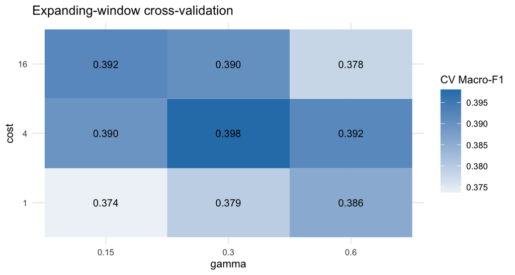

```r
ggplot(cv_ref, aes(factor(gamma), factor(cost), fill = cv_macro_f1)) +
  geom_tile() +
  geom_text(aes(label = sprintf("%.3f", cv_macro_f1)), size = 3) +
  scale_fill_gradient(low = "#eef3f7", high = "#2c7fb8") +
  labs(x = "gamma", y = "cost", fill = "CV Macro-F1",
       title = "Expanding-window cross-validation") +
  theme_minimal(base_size = 9)
```

## Kernel choice

Plan §8 lists kernel as a tuning decision. A linear kernel is compared with the RBF kernel on the same five validation folds, so the choice rests on validation evidence rather than test performance.

```r
# gamma is ignored by a linear kernel; a value is supplied only to satisfy the call
lin_cv <- cv_svm(REFINED_FEATURES, CJ(cost = c(0.25, 1, 4), gamma = 0.3),
                 kernel = "linear")
best_lin <- lin_cv[which.max(cv_macro_f1)]

kernel_cmp <- data.table(
  kernel      = c("Linear", "RBF (radial)"),
  best_cost   = c(best_lin$cost, best$cost),
  best_gamma  = c(NA_real_, best$gamma),
  cv_macro_f1 = c(best_lin$cv_macro_f1, best$cv_macro_f1))
knitr::kable(kernel_cmp, digits = 3,
             caption = "Kernel comparison on the five validation folds")
```

Kernel comparison on the five validation folds

| kernel | best_cost | best_gamma | cv_macro_f1 |
| --- | --- | --- | --- |
| Linear | 1 | NA | 0.374 |
| RBF (radial) | 4 | 0.3 | 0.398 |

The RBF kernel is carried forward on validation Macro-F1 (0.398 against 0.374 for linear), consistent with the bivariate EDA finding that no single feature separates the three outcome classes linearly.

Best configuration: **cost = 4, gamma = 0.3**, mean validation Macro-F1 0.398.

# Baseline and final test

The Final Test set is used **once**, here.

```r
fit_eval <- function(features, cost, gamma, label) {
  prep <- fit_prep(train, features)
  m <- svm(apply_prep(prep, train), train$result,
           kernel = "radial", cost = cost, gamma = gamma)
  p <- predict(m, apply_prep(prep, test))
  res <- evaluate_model(test$result, p)
  list(res = res, row = metrics_row(res, "SVM", label))
}

base_grid <- CJ(cost = c(0.5, 1, 4), gamma = c(0.05, 0.15))
cv_base   <- cv_svm(BASE_FEATURES, base_grid)
bb        <- cv_base[which.max(cv_macro_f1)]

baseline <- fit_eval(BASE_FEATURES,    bb$cost,   bb$gamma,   "Baseline (league + season progress)")
refined  <- fit_eval(REFINED_FEATURES, best$cost, best$gamma,
                     "Refined, predict() class rule")

majority <- metrics_row(
  evaluate_model(test$result, rep("home_win", nrow(test))),
  "Majority class", "Always home_win")

comparison <- rbind(majority, baseline$row, refined$row)
knitr::kable(comparison[, c("model","stage","accuracy","balanced_accuracy","macro_f1")],
             digits = 3, row.names = FALSE)
```

| model | stage | accuracy | balanced_accuracy | macro_f1 |
| --- | --- | --- | --- | --- |
| Majority class | Always home_win | 0.430 | 0.333 | 0.201 |
| SVM | Baseline (league + season progress) | 0.430 | 0.333 | 0.201 |
| SVM | Refined, predict() class rule | 0.481 | 0.424 | 0.397 |

```r
knitr::kable(refined$res$per_class, digits = 3,
             caption = "Refined SVM — per-class performance on the Final Test set")
```

Refined SVM — per-class performance on the Final Test set

| class | precision | recall | f1 | support | predicted |
| --- | --- | --- | --- | --- | --- |
| home_win | 0.512 | 0.749 | 0.608 | 2262 | 3308 |
| draw | 0.271 | 0.085 | 0.129 | 1346 | 420 |
| away_win | 0.473 | 0.438 | 0.455 | 1648 | 1528 |

```r
refined$res$confusion
```

```
          Truth
Predicted  home_win draw away_win
  home_win     1694  853      761
  draw          141  114      165
  away_win      427  379      722
```

# Tuned decision weights

Both LDA and Random Forest add a decision-weight stage, so the SVM is given the same treatment for a like-for-like comparison. The most-probable-class rule rarely selects `draw`, because a draw is seldom the single highest-probability outcome. Multiplying each class posterior by a weight before taking the argmax lowers the bar for draws and away wins. The weights are chosen on the five validation folds only; the model itself is unchanged.

```r
# Posterior probabilities on each validation fold (one fit per fold)
fold_probs <- lapply(folds, function(f) {
  tr <- train[f$train, ]; va <- train[f$valid, ]
  prep <- fit_prep(tr, REFINED_FEATURES)
  m <- svm(apply_prep(prep, tr), tr$result, kernel = "radial",
           cost = best$cost, gamma = best$gamma, probability = TRUE)
  p <- predict(m, apply_prep(prep, va), probability = TRUE)
  list(prob = attr(p, "probabilities")[, levels(train$result), drop = FALSE],
       truth = va$result)
})

# Weight search is free once the probabilities are stored
weight_grid <- CJ(w_draw = seq(1, 2.4, by = 0.05),
                  w_away = seq(0.7, 1.9, by = 0.05))

apply_weights <- function(prob, w_draw, w_away) {
  W <- sweep(prob, 2, c(home_win = 1, draw = w_draw, away_win = w_away), `*`)
  factor(colnames(W)[max.col(W, ties.method = "first")],
         levels = levels(train$result))
}

weight_cv <- weight_grid[, .(cv_macro_f1 = mean(vapply(fold_probs, function(fp)
    evaluate_model(fp$truth, apply_weights(fp$prob, w_draw, w_away))$overall$macro_f1,
    numeric(1)))), by = .(w_draw, w_away)]

best_w <- weight_cv[which.max(cv_macro_f1)]
plain_cv <- mean(vapply(fold_probs, function(fp)
  evaluate_model(fp$truth, apply_weights(fp$prob, 1, 1))$overall$macro_f1, numeric(1)))
```

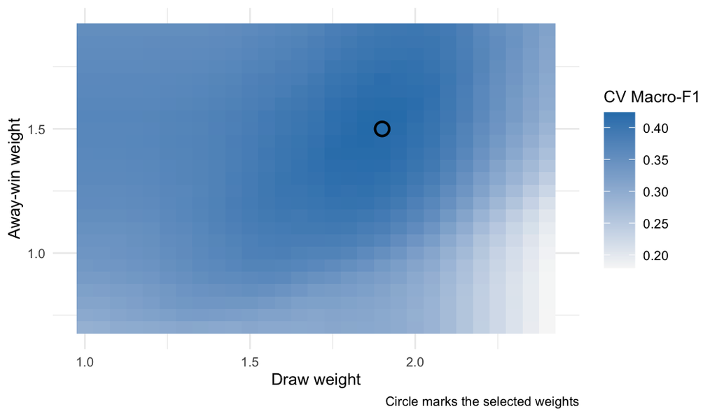

```r
ggplot(weight_cv, aes(w_draw, w_away, fill = cv_macro_f1)) +
  geom_raster() +
  geom_point(data = best_w, shape = 21, size = 3, stroke = 1, fill = NA) +
  scale_fill_gradient(low = "#f7f7f7", high = "#2c7fb8") +
  labs(x = "Draw weight", y = "Away-win weight", fill = "CV Macro-F1",
       caption = "Circle marks the selected weights") +
  theme_minimal(base_size = 9)
```

Selected weights: home 1 / draw **1.9** / away **1.5**, validation Macro-F1 0.424 against 0.339 for the unweighted rule.

```r
prep_full <- fit_prep(train, REFINED_FEATURES)
m_full <- svm(apply_prep(prep_full, train), train$result, kernel = "radial",
              cost = best$cost, gamma = best$gamma, probability = TRUE)
p_test <- predict(m_full, apply_prep(prep_full, test), probability = TRUE)
prob_test <- attr(p_test, "probabilities")[, levels(train$result), drop = FALSE]

# Both rows come from the SAME probability matrix, so the difference between
# them is the decision weights alone. The earlier "Refined" row used the class
# labels returned by predict(), which is a different decision rule.
unweighted <- evaluate_model(test$result, apply_weights(prob_test, 1, 1))
weighted   <- evaluate_model(test$result,
                             apply_weights(prob_test, best_w$w_draw, best_w$w_away))

comparison <- rbind(comparison,
  metrics_row(unweighted, "SVM", "Refined, probability argmax (unweighted)"),
  metrics_row(weighted,   "SVM", "Refined, tuned decision weights (final)"))

knitr::kable(comparison[, c("model","stage","accuracy","balanced_accuracy","macro_f1")],
             digits = 3, row.names = FALSE)
```

| model | stage | accuracy | balanced_accuracy | macro_f1 |
| --- | --- | --- | --- | --- |
| Majority class | Always home_win | 0.430 | 0.333 | 0.201 |
| SVM | Baseline (league + season progress) | 0.430 | 0.333 | 0.201 |
| SVM | Refined, predict() class rule | 0.481 | 0.424 | 0.397 |
| SVM | Refined, probability argmax (unweighted) | 0.491 | 0.420 | 0.361 |
| SVM | Refined, tuned decision weights (final) | 0.455 | 0.427 | 0.423 |

```r
knitr::kable(weighted$per_class, digits = 3,
             caption = "Weighted SVM — per-class performance on the Final Test set")
```

Weighted SVM — per-class performance on the Final Test set

| class | precision | recall | f1 | support | predicted |
| --- | --- | --- | --- | --- | --- |
| home_win | 0.533 | 0.568 | 0.550 | 2262 | 2409 |
| draw | 0.275 | 0.218 | 0.243 | 1346 | 1065 |
| away_win | 0.458 | 0.495 | 0.476 | 1648 | 1782 |

```r
weighted$confusion
```

```
          Truth
Predicted  home_win draw away_win
  home_win     1285  616      508
  draw          448  293      324
  away_win      529  437      816
```

```r
test_predictions <- data.table(
  game_id   = test$game_id,
  date      = test$date,
  truth     = test$result,
  pred_unweighted = apply_weights(prob_test, 1, 1),
  pred_final      = apply_weights(prob_test, best_w$w_draw, best_w$w_away),
  p_home_win = prob_test[, "home_win"],
  p_draw     = prob_test[, "draw"],
  p_away_win = prob_test[, "away_win"])

fwrite(comparison,       "outputs/member4_svm_comparison_row.csv")
fwrite(test_predictions, "outputs/member4_svm_test_predictions.csv")

saveRDS(list(cv_rbf      = cv_ref,
             cv_linear   = lin_cv,
             best        = best,
             best_weights = best_w,
             weight_cv   = weight_cv,
             baseline_params = bb,
             comparison  = comparison,
             test_plain      = refined$res,
             test_unweighted = unweighted,
             test_weighted   = weighted,
             test_predictions = test_predictions),
        "outputs/member4_svm_results.rds")
```

# Standard reporting format (plan §9)

- **Model:** Support Vector Machine (RBF kernel, `e1071::svm`)
- **Features:** 9 refined features (§2)
- **Preprocessing:** median imputation + standardisation, both fitted inside each training fold; one-hot encoding for `competition_id`
- **Baseline result:** Macro-F1 0.201, Accuracy 43.0%
- **Best hyperparameters:** kernel = radial, cost = 4, gamma = 0.3; decision weights home/draw/away = 1 / 1.9 / 1.5
- **Validation Macro-F1:** 0.424 with tuned weights (0.339 unweighted)
- **Test Accuracy:** 45.5%
- **Test Balanced Accuracy:** 42.7%
- **Test Macro-F1:** 0.423
- **Per-class and confusion matrix:** above

**Main finding.** With the engineered pre-match features and tuned decision weights (draw 1.9, away 1.5), the SVM reaches a test Macro-F1 of 0.423 and accuracy 45.5%, against 0.201 and 43.0% for always predicting a home win; the context-only baseline collapsed to that same majority rule, confirming the form features carry the signal. Holding the probability output fixed, the weights raise Macro-F1 from 0.361 to 0.423 and draw recall from 0.004 to 0.218, at a cost of 3.6% accuracy. Validation and test Macro-F1 are close (0.424 and 0.423), so this run shows no marked drop from validation to test.

**Limitation.** Probability estimates from `e1071::svm` come from Platt scaling fitted after training rather than from the model itself, which limits how much decision-weight tuning can lift minority-class recall compared with a probabilistic classifier such as LDA; draws remain the hardest class (F1 0.243), since the engineered differentials describe relative team strength rather than the closeness that produces a draw.